# Indel Signature InsDel_O

# InsDel_O

**Note**

InsDel_O and InsDel_1a as extracted in the 89-type classification have cosine similarity of 0.91 and as extracted in the 476-type classification have cosine similarity of 0.95. On balance we think they are different because of the deletions with microhomology in InsDel1a and the deletions of single Ts in long-poly-T contexts in InsDel_O.

(corresponds to 83-type signature ID_O)

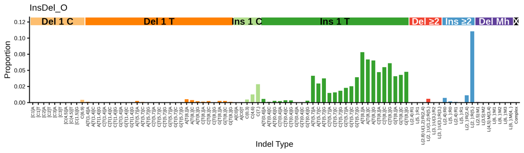

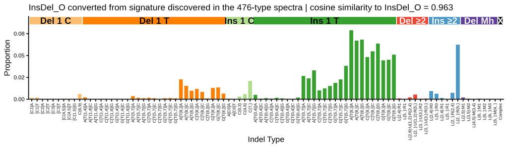

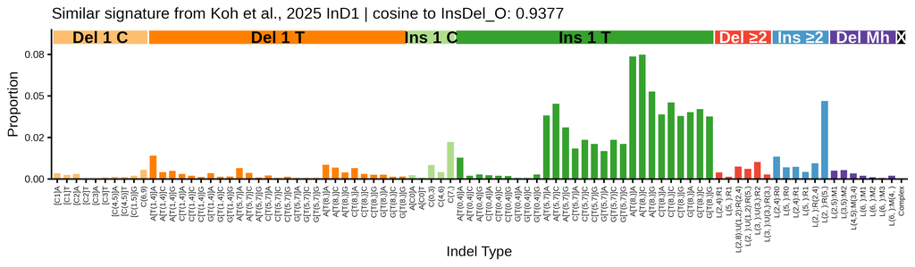

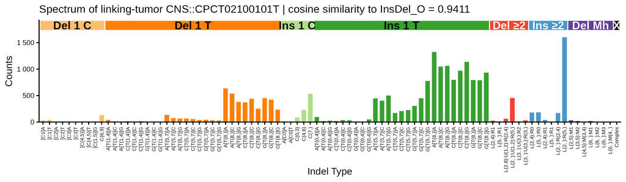

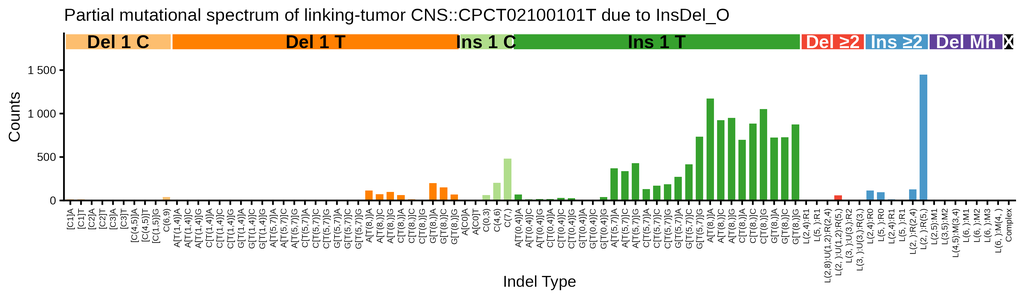

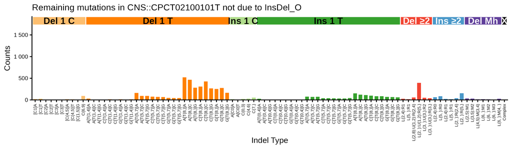

## 476-type representations corresponding to InsDel_O

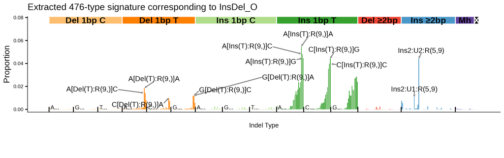

476-type spectrum of the linking tumor CNS::CPCT02100101T; cosine similarity to the extracted 476-type signature is 0.9688

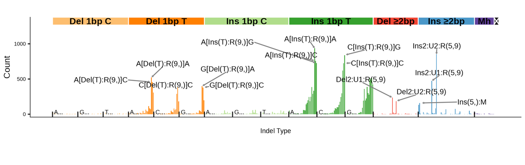

## 83-type signature corresponding to InsDel_O (ID_O)

**Note**

WARNING: The 83-type ID_O extraction excluded the large proportion of T insertions in long poly-T contexts that were detected in extractions in the 89-type and 476-type classifications. This accounts for the low cosine similarity between the 83-type signature ID_O and the 476-type signature collapsed to the 83-type classification.

In the plot of the 83-type signature converted from the extracted 476-type signature these account for 75% of mutations and the other mutation classes are barely visible.

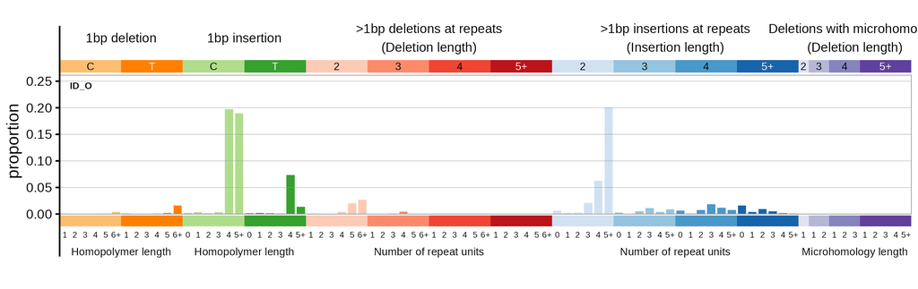

83-type signature converted from signature discovered in the 476-type spectra | cosine similarity to ID_O: 0.1024

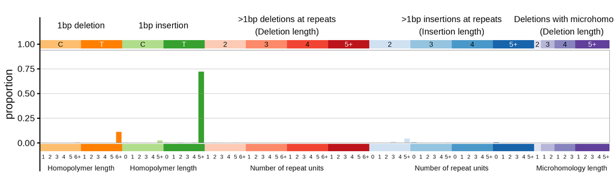

**Click here to see with insertions and deletions of T in long poly-T suppressed**

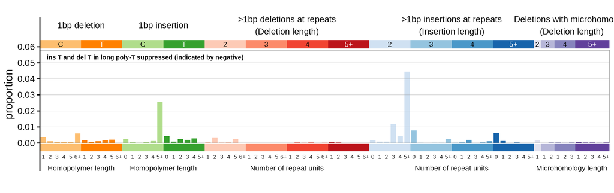

**Caution**

For the linking tumor plot, mutation counts for insertions and deletions of T in long-poly-T contexts were set to 0. They were also set to 0 when calculating cosine similarity with the signature. The signature was not altered when computing the cosine similarity.

83-type spectrum of the linking tumor CNS::CPCT02100101T | cosine similarly to ID_O: 0.8015

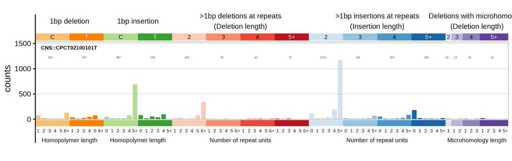